# Explore the NOAA Storm Database

hoaihuongbk

June 1, 2019

## Introduction

Storms and other severe weather events can cause both public health and economic problems for communities and municipalities. Many severe events can result in fatalities, injuries, and property damage, and preventing such outcomes to the extent possible is a key concern.

This project involves exploring the U.S. National Oceanic and Atmospheric Administration’s (NOAA) storm database. This database tracks characteristics of major storms and weather events in the United States, including when and where they occur, as well as estimates of any fatalities, injuries, and property damage.

In this report, I focus on explore the database source and answer 2 questions:

1. Across the United States, which types of events (as indicated in the EVTYPE variable) are most harmful with respect to population health?
2. Across the United States, which types of events have the greatest economic consequences?

## Data Processing

The data for this report come in the form of a comma-separated-value file compressed via the bzip2 algorithm to reduce its size.

### Download data from source

```r
fileUrl <- "https://d396qusza40orc.cloudfront.net/repdata%2Fdata%2FStormData.csv.bz2"
download.file(fileUrl, destfile = "storm_data.csv.bz2")
stormData <- read.csv("storm_data.csv.bz2", stringsAsFactors = FALSE)
```

### Show structure

```r
str(stormData)
```

```
## 'data.frame':    902297 obs. of  37 variables:
##  $ STATE__   : num  1 1 1 1 1 1 1 1 1 1 ...
##  $ BGN_DATE  : chr  "4/18/1950 0:00:00" "4/18/1950 0:00:00" "2/20/1951 0:00:00" "6/8/1951 0:00:00" ...
##  $ BGN_TIME  : chr  "0130" "0145" "1600" "0900" ...
##  $ TIME_ZONE : chr  "CST" "CST" "CST" "CST" ...
##  $ COUNTY    : num  97 3 57 89 43 77 9 123 125 57 ...
##  $ COUNTYNAME: chr  "MOBILE" "BALDWIN" "FAYETTE" "MADISON" ...
##  $ STATE     : chr  "AL" "AL" "AL" "AL" ...
##  $ EVTYPE    : chr  "TORNADO" "TORNADO" "TORNADO" "TORNADO" ...
##  $ BGN_RANGE : num  0 0 0 0 0 0 0 0 0 0 ...
##  $ BGN_AZI   : chr  "" "" "" "" ...
##  $ BGN_LOCATI: chr  "" "" "" "" ...
##  $ END_DATE  : chr  "" "" "" "" ...
##  $ END_TIME  : chr  "" "" "" "" ...
##  $ COUNTY_END: num  0 0 0 0 0 0 0 0 0 0 ...
```

[output cut: 23 more lines]

You can see the *EVTYPE* column is factor and *BGN_DATE* is date. We can convert them to these data types.

### Convert some data type

```r
stormData$BGN_DATE <- as.Date(stormData$BGN_DATE, "%m/%d/%Y %H:%M:%S")
stormData$EVTYPE <- as.factor(stormData$EVTYPE)
```

### Answer the questions

#### Across the United States, which types of events (as indicated in the EVTYPE variable) are most harmful with respect to population health?

You can see the column *FATALITIES* in database, so first summarise total of this column per EVTYPE, and then select the EVTYPE which max total.

```r
if(!require("dplyr")) install.packages("dplyr")
library(dplyr)
stormData_PerEvType <- stormData %>%
        group_by(EVTYPE) %>%
        summarise(TOTAL_FATALITIES=sum(FATALITIES))
summary(stormData_PerEvType)
```

```
##                    EVTYPE    TOTAL_FATALITIES
##     HIGH SURF ADVISORY:  1   Min.   :   0.00
##   COASTAL FLOOD       :  1   1st Qu.:   0.00
##   FLASH FLOOD         :  1   Median :   0.00
##   LIGHTNING           :  1   Mean   :  15.38
##   TSTM WIND           :  1   3rd Qu.:   0.00
##   TSTM WIND (G45)     :  1   Max.   :5633.00
##  (Other)              :979
```

Select top 3 row arrange by *TOTAL_FATALITIES* descending

```r
stormData_PerEvType %>% arrange(desc(TOTAL_FATALITIES)) %>% top_n(3)
```

```
## # A tibble: 3 x 2
##   EVTYPE         TOTAL_FATALITIES
##   <fct>                     <dbl>
## 1 TORNADO                    5633
## 2 EXCESSIVE HEAT             1903
## 3 FLASH FLOOD                 978
```

You can see the top 3 match which EVTYPE in TORNADO, EXCESSIVE HEAT and FLASH FLOOD. See more in Results section.

#### Across the United States, which types of events have the greatest economic consequences?

You can see the column *PROPDMG* in database, so first summarise total of this column per EVTYPE, and then select the EVTYPE which max total.

Before we will convert PROPDMG column to real value which indicated by *PROPDMGEXP* column (B,M,K)

```r
stormData$PROPDMGEXP <- as.factor(stormData$PROPDMGEXP)
stormData_PerEvType2 <- stormData %>%
        mutate(
                PROPDMG = ifelse(PROPDMGEXP == 'B', PROPDMG * 1000000000,
                                 ifelse(PROPDMGEXP == 'M', PROPDMG * 1000000,
                                        ifelse(PROPDMGEXP == 'K', PROPDMG * 1000, PROPDMG)))) %>%
        group_by(EVTYPE) %>%
        summarise(TOTAL_PROPDMG=sum(PROPDMG))
summary(stormData_PerEvType2)
```

```
##                    EVTYPE    TOTAL_PROPDMG
##     HIGH SURF ADVISORY:  1   Min.   :0.000e+00
##   COASTAL FLOOD       :  1   1st Qu.:0.000e+00
##   FLASH FLOOD         :  1   Median :0.000e+00
##   LIGHTNING           :  1   Mean   :4.338e+08
##   TSTM WIND           :  1   3rd Qu.:5.105e+04
##   TSTM WIND (G45)     :  1   Max.   :1.447e+11
##  (Other)              :979
```

Select top 1 row arrange by *TOTAL_PROPDMG* descending

```r
stormData_PerEvType2 %>% arrange(desc(TOTAL_PROPDMG)) %>% top_n(1)
```

```
## # A tibble: 1 x 2
##   EVTYPE TOTAL_PROPDMG
##   <fct>          <dbl>
## 1 FLOOD   144657709807
```

You can see the FLOOD event is greatest economic consequences. See more in Results section.

## Results

### Across the United States, which types of events (as indicated in the EVTYPE variable) are most harmful with respect to population health?

Answer: TORNADO, EXCESSIVE HEAT and FLASH FLOOD

Plot these data to yearly chart for see more respect

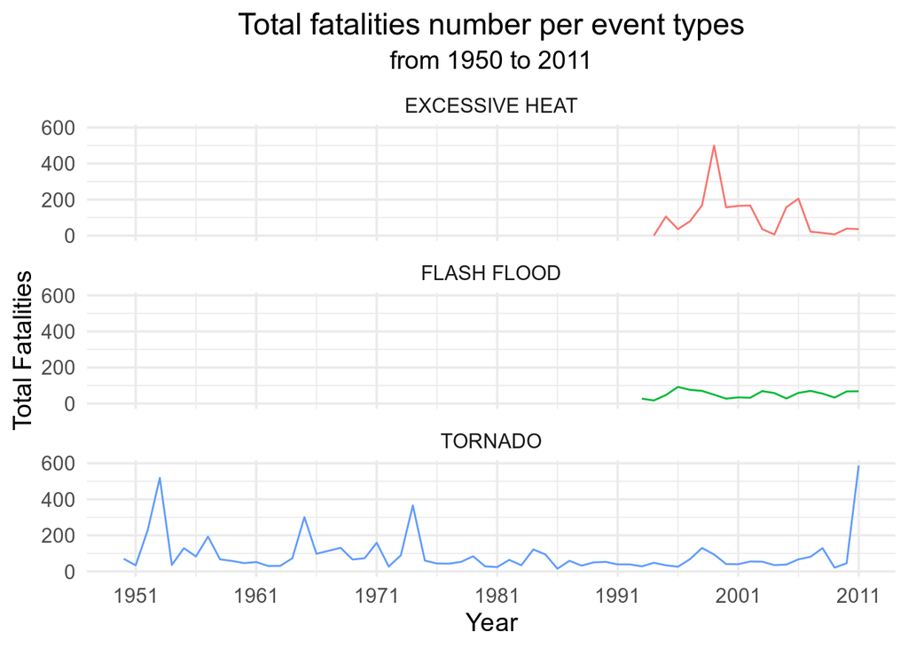

```r
if(!require("ggplot2")) install.packages("ggplot2")
library(ggplot2)
stormData_Top3 <- stormData %>%
        filter(EVTYPE %in% c('TORNADO', 'EXCESSIVE HEAT', 'FLASH FLOOD')) %>%
        mutate(YEAR = as.integer(format(BGN_DATE, "%Y"))) %>%
        group_by(EVTYPE, YEAR) %>%
        summarise(TOTAL_FATALITIES=sum(FATALITIES))

ggplot(data=stormData_Top3, aes(x=YEAR, y=TOTAL_FATALITIES, group=EVTYPE)) +
        geom_line(aes(color=EVTYPE)) + facet_wrap(.~EVTYPE, ncol = 1) +
        scale_x_continuous(breaks=seq(1951, 2011, 10)) +
        labs(title="Total fatalities number per event types", subtitle = "from 1950 to 2011", x="Year", y="Total Fatalities") +
        theme_minimal(base_size = 14) +
        theme(plot.title = element_text(hjust = 0.5), plot.subtitle = element_text(hjust = 0.5)) +
        theme(legend.position = "none")
```

### Across the United States, which types of events have the greatest economic consequences?

Answer: FLOOD

Plot these data to yearly chart for see more respect. Note we just show data with PROPDMGEXP is in K, M, B values.

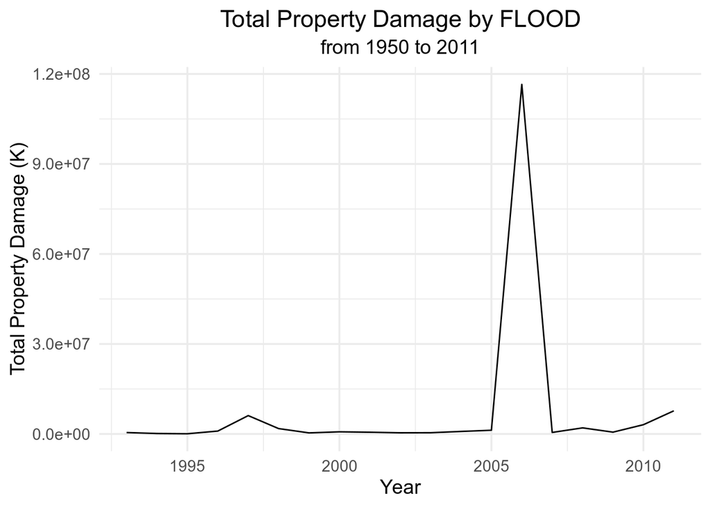

```r
stormData_Flood <- stormData %>% filter(EVTYPE == 'FLOOD', PROPDMGEXP %in% c("K", "M", "B")) %>%
        mutate(
                YEAR = as.integer(format(BGN_DATE, "%Y")),
                PROPDMG = ifelse(PROPDMGEXP == 'B', PROPDMG * 1000000,
                                 ifelse(PROPDMGEXP == 'M', PROPDMG * 1000, PROPDMG))
                ) %>%
        group_by(YEAR) %>%
        summarise(TOTAL_PROPDMG=sum(PROPDMG))

ggplot(data=stormData_Flood, aes(x=YEAR, y=TOTAL_PROPDMG)) +
        geom_line() +
        labs(title="Total Property Damage by FLOOD", subtitle = "from 1950 to 2011", x="Year", y="Total Property Damage (K)") +
        theme_minimal(base_size = 14) +
        theme(plot.title = element_text(hjust = 0.5), plot.subtitle = element_text(hjust = 0.5)) +
        theme(legend.position = "none")
```